# Baco et al Anova plots and mean SD summaries

Rebecca Ross

Last Rendered on 15 December, 2022

This script was used to generating the ANOVA results associated with Baco et al. “Towards a Scientific Community Consensus on Designating Vulnerable Marine Ecosystems from Imagery” paper.

Confessions of the coder, there are definitely some inefficiencies here:

- repeat functions are not in loops but instead coded a line per taxa
- one anova algorithm works with plot labelling, the other with Tukey HSD, we did not find one that works with both. So we used both algorithms (but did check they gave the same result!)
- the anova plots’ Y label font size would not cooperate when the y axis was broken so those labels were replaced in a picture editor for publication figures

Other notes for readers:

- when viewing this script as html, the squashed look of the y axis tick labels is not evident when saved to file.
- the inputs and outputs are still at the original locations and are not customised for you. Please edit if you want to run this script yourself.

# Libraries

```r
library(ggpubr)
library(rstatix)
library(gg.gap)
library(tidyverse)
```

Note that this is not customised for you, the reader, it is still set at the actual location of the file that was used.

```r
data.all.incLT1m2<-read.csv("I:/Papers_development/13 Amy Baco VME skypes SUBMITTED/Amy_Data_R_noHolo.csv", sep= ",", header=TRUE, row.names=NULL)

#subset to only images with field of view greater than 1m2
data.all<-subset(data.all.incLT1m2,subset = data.all.incLT1m2$FOV_m2>1)
```

# Data Management

## Tidy up

Check columns are in the right formats, remove NAs.

```r
data.all$VME_YMN<-as.factor(data.all$VME_YMN)
data.cln<-data.all[!is.na(data.all$VME_YMN),]
data.cln$VME_YMN<-factor(data.cln$VME_YMN,levels=c("Y","M","N"))

summary(data.cln)
```

```
     Index        original.ordder   All.sites         Scleractinian        Octocorals       Pennatulacea     Anitpatharians
 Min.   :   1.0   Min.   :   1.0   Length:1235        Min.   : 0.00000   Min.   : 0.0000   Min.   :0.00000   Min.   :0.0000
 1st Qu.: 335.5   1st Qu.: 352.5   Class :character   1st Qu.: 0.00000   1st Qu.: 0.0000   1st Qu.:0.00000   1st Qu.:0.0000
 Median : 656.0   Median : 696.0   Mode  :character   Median : 0.00000   Median : 0.0000   Median :0.00000   Median :0.0000
 Mean   : 646.0   Mean   : 682.4                      Mean   : 0.36915   Mean   : 0.4024   Mean   :0.02368   Mean   :0.0895
 3rd Qu.: 964.5   3rd Qu.:1022.5                      3rd Qu.: 0.06575   3rd Qu.: 0.1972   3rd Qu.:0.00000   3rd Qu.:0.0000
 Max.   :1273.0   Max.   :1331.0                      Max.   :53.82675   Max.   :22.1662   Max.   :4.08675   Max.   :4.7755
                                                      NA's   :5
    Sponges           Anemones           Crinoids       Xenophyophores       Bryozoans       Stylasterids_Anthoathecata   Brisingids
 Min.   : 0.0000   Min.   : 0.00000   Min.   :  0.000   Min.   : 0.00000   Min.   : 0.0000   Min.   : 0.0000            Min.   :0.00000
 1st Qu.: 0.0000   1st Qu.: 0.00000   1st Qu.:  0.000   1st Qu.: 0.00000   1st Qu.: 0.0000   1st Qu.: 0.0000            1st Qu.:0.00000
 Median : 0.0000   Median : 0.00000   Median :  0.000   Median : 0.00000   Median : 0.0000   Median : 0.0000            Median :0.00000
 Mean   : 0.4694   Mean   : 0.23128   Mean   :  1.006   Mean   : 0.09826   Mean   : 0.0462   Mean   : 0.2677            Mean   :0.04131
 3rd Qu.: 0.2593   3rd Qu.: 0.06575   3rd Qu.:  0.000   3rd Qu.: 0.00000   3rd Qu.: 0.0000   3rd Qu.: 0.0000            3rd Qu.:0.00000
 Max.   :43.6374   Max.   :60.55509   Max.   :101.613   Max.   :12.39709   Max.   :15.9619   Max.   :27.3333            Max.   :8.73831

   Ascidians          Zoanthids         Brachiopoda         Hydroidea         Echinoids         Ophiuroids       Chemosynthetic_taxa
 Min.   :0.000000   Min.   : 0.00000   Min.   :0.000000   Min.   :0.00000   Min.   : 0.0000   Min.   :  0.0000   Min.   :0
 1st Qu.:0.000000   1st Qu.: 0.00000   1st Qu.:0.000000   1st Qu.:0.00000   1st Qu.: 0.0000   1st Qu.:  0.0000   1st Qu.:0
 Median :0.000000   Median : 0.00000   Median :0.000000   Median :0.00000   Median : 0.0000   Median :  0.0000   Median :0
 Mean   :0.006051   Mean   : 0.04918   Mean   :0.004658   Mean   :0.01956   Mean   : 0.1069   Mean   :  0.5585   Mean   :0
 3rd Qu.:0.000000   3rd Qu.: 0.00000   3rd Qu.:0.000000   3rd Qu.:0.00000   3rd Qu.: 0.0000   3rd Qu.:  0.0000   3rd Qu.:0
 Max.   :1.858558   Max.   :44.87377   Max.   :5.138218   Max.   :5.77508   Max.   :18.1325   Max.   :163.4699   Max.   :0

    Bivalvia        Poly_plus_Serpulidae    Decapoda      OldOverallDensity  OldTaxa_per_m2   OldTotal_taxa      Total_taxa
 Min.   : 0.00000   Min.   : 0.00000     Min.   :0.0000   Min.   :  0.0500   Min.   :0.0220   Min.   : 1.000   Min.   :1.00
 1st Qu.: 0.00000   1st Qu.: 0.00000     1st Qu.:0.0000   1st Qu.:  0.3158   1st Qu.:0.1348   1st Qu.: 2.000   1st Qu.:2.00
 Median : 0.00000   Median : 0.00000     Median :0.0000   Median :  1.0354   Median :0.2548   Median : 3.000   Median :3.00
 Mean   : 0.03282   Mean   : 0.08743     Mean   :0.1019   Mean   :  4.1116   Mean   :0.5726   Mean   : 3.104   Mean   :2.92
 3rd Qu.: 0.00000   3rd Qu.: 0.00000     3rd Qu.:0.0000   3rd Qu.:  3.8343   3rd Qu.:0.6586   3rd Qu.: 4.000   3rd Qu.:4.00
 Max.   :20.02002   Max.   :39.76543     Max.   :5.8191   Max.   :184.7210   Max.   :6.5307   Max.   :10.000   Max.   :9.00

 OverallDensity     Taxa_per_m2    CountCoverDensity  VME_YMN Scler_pc_liveFramewk Scler_pc_allFramewk  hard_sub_pc
 Min.   :  0.030   Min.   :0.020   Length:1235        Y:293   Min.   : 0.000       Min.   :  0.00      Min.   :  0.00
 1st Qu.:  0.320   1st Qu.:0.130   Class :character   M:290   1st Qu.: 0.000       1st Qu.:  0.00      1st Qu.:  0.00
 Median :  0.980   Median :0.250   Mode  :character   N:652   Median : 0.000       Median : 19.00      Median : 75.00
 Mean   :  4.011   Mean   :0.536                              Mean   : 6.136       Mean   : 37.82      Mean   : 55.05
 3rd Qu.:  3.625   3rd Qu.:0.625                              3rd Qu.: 0.750       3rd Qu.: 83.00      3rd Qu.: 95.00
 Max.   :184.720   Max.   :6.530                              Max.   :90.000       Max.   :100.00      Max.   :100.00
                                                              NA's   :1169         NA's   :1048        NA's   :81
```

[output cut: 9 more lines]

```
 Length:1235        Length:1235        Length:1235        Length:1235        Length:1235        Length:1235        Length:1235
 Class :character   Class :character   Class :character   Class :character   Class :character   Class :character   Class :character
 Mode  :character   Mode  :character   Mode  :character   Mode  :character   Mode  :character   Mode  :character   Mode  :character




   Notes_1            Notes_2             Notes_3
 Length:1235        Length:1235        Min.   :147.2
 Class :character   Class :character   1st Qu.:147.2
 Mode  :character   Mode  :character   Median :147.2
                                       Mean   :147.2
                                       3rd Qu.:147.2
                                       Max.   :147.2
                                       NA's   :1186
```

## Subset to presence only

I.e. ensure we ignore the 0s.

```r
data.sc<-subset(data.cln,Scleractinian>0)
data.oc<-subset(data.cln,Octocorals>0)
data.pn<-subset(data.cln,Pennatulacea>0)
data.an<-subset(data.cln,Anitpatharians>0)
data.sp<-subset(data.cln,Sponges>0)
data.xe<-subset(data.cln,Xenophyophores>0)
data.rf<-subset(data.cln,Scler_pc_allFramewk>0)
data.st<-subset(data.cln,Stylasterids_Anthoathecata>0)

# summary(data.sc$Scleractinian)
# summary(data.oc$Octocorals)
# summary(data.pn$Pennatulacea)
# summary(data.an$Anitpatharians)
# summary(data.sp$Sponges)
# summary(data.xe$Xenophyophores)
# summary(data.rf$Scler_pc_allFramewk)
```

# Analyses

## Make summary stats for each taxon/category

```r
OD.stat<-data.cln%>%
  group_by(VME_YMN) %>%
  summarise_at(vars(OverallDensity), funs(mean,sd,n(),min,max))
TT.stat<-data.cln%>%
  group_by(VME_YMN) %>%
  summarise_at(vars(Total_taxa), funs(mean,sd,n(),min,max))
TM.stat<-data.cln%>%
  group_by(VME_YMN) %>%
  summarise_at(vars(Taxa_per_m2), funs(mean,sd,n(),min,max))

SC.stat<-data.sc%>%
  group_by(VME_YMN) %>%
  summarise_at(vars(Scleractinian), funs(mean,sd,n(),min,max))
OC.stat<-data.oc%>%
  group_by(VME_YMN) %>%
  summarise_at(vars(Octocorals), funs(mean,sd,n(),min,max))
PN.stat<-data.pn%>%
  group_by(VME_YMN) %>%
  summarise_at(vars(Pennatulacea), funs(mean,sd,n(),min,max))
AN.stat<-data.an%>%
  group_by(VME_YMN) %>%
  summarise_at(vars(Anitpatharians), funs(mean,sd,n(),min,max))
SP.stat<-data.sp%>%
  group_by(VME_YMN) %>%
  summarise_at(vars(Sponges), funs(mean,sd,n(),min,max))
XE.stat<-data.xe%>%
  group_by(VME_YMN) %>%
  summarise_at(vars(Xenophyophores), funs(mean,sd,n(),min,max))
RF.stat<-data.rf%>%
  group_by(VME_YMN) %>%
  summarise_at(vars(Scler_pc_allFramewk), funs(mean,sd,n(),min,max))

ST.stat<-data.st%>%
  group_by(VME_YMN) %>%
  summarise_at(vars(Stylasterids_Anthoathecata), funs(mean,sd,n(),min,max))

# view summaries
OD.stat
```

| VME_YMN | mean | sd | n | min | max |
| --- | --- | --- | --- | --- | --- |
| Y | 5.999863 | 11.470937 | 293 | 0.17 | 125.32 |
| M | 5.808793 | 11.654379 | 290 | 0.10 | 116.13 |
| N | 2.316672 | 8.571844 | 652 | 0.03 | 184.72 |

```r
TT.stat
```

| VME_YMN | mean | sd | n | min | max |
| --- | --- | --- | --- | --- | --- |
| Y | 3.928328 | 1.617006 | 293 | 1 | 9 |
| M | 3.610345 | 1.689545 | 290 | 1 | 9 |
| N | 2.159509 | 1.241506 | 652 | 1 | 8 |

```r
TM.stat
```

| VME_YMN | mean | sd | n | min | max |
| --- | --- | --- | --- | --- | --- |
| Y | 0.6129693 | 0.7910612 | 293 | 0.05 | 6.53 |
| M | 0.8026897 | 0.8771720 | 290 | 0.05 | 6.17 |
| N | 0.3828528 | 0.5318938 | 652 | 0.02 | 4.59 |

```r
SC.stat
```

| VME_YMN | mean | sd | n | min | max |
| --- | --- | --- | --- | --- | --- |
| Y | 3.593646 | 9.320525 | 73 | 0.06574622 | 53.82675 |
| M | 1.246716 | 2.119023 | 99 | 0.06574622 | 12.72220 |
| N | 0.484316 | 2.175313 | 141 | 0.03883284 | 25.40485 |

```r
OC.stat
```

| VME_YMN | mean | sd | n | min | max |
| --- | --- | --- | --- | --- | --- |
| Y | 1.4670619 | 2.707179 | 224 | 0.02000000 | 22.16625 |
| M | 0.7950741 | 2.291544 | 150 | 0.05135838 | 18.31276 |
| N | 0.2923862 | 1.149579 | 168 | 0.02533403 | 14.73093 |

```r
PN.stat
```

| VME_YMN | mean | sd | n | min | max |
| --- | --- | --- | --- | --- | --- |
| Y | 1.9202060 | 2.1267293 | 4 | 0.08527752 | 4.086748 |
| M | 0.6045382 | 0.8006362 | 26 | 0.05135838 | 3.055071 |
| N | 0.1358799 | 0.2038329 | 43 | 0.02769830 | 1.407373 |

```r
AN.stat
```

| VME_YMN | mean | sd | n | min | max |
| --- | --- | --- | --- | --- | --- |
| Y | 0.4182730 | 0.6989578 | 97 | 0.02000000 | 4.775541 |
| M | 0.5228431 | 0.5453957 | 91 | 0.03403279 | 3.444259 |
| N | 0.2762293 | 0.4796840 | 81 | 0.03270069 | 3.683444 |

```r
SP.stat
```

| VME_YMN | mean | sd | n | min | max |
| --- | --- | --- | --- | --- | --- |
| Y | 1.2947888 | 3.7225934 | 177 | 0.05000000 | 43.637387 |
| M | 1.4752650 | 2.2075703 | 158 | 0.03403279 | 11.867916 |
| N | 0.5844921 | 0.9174321 | 201 | 0.02104179 | 6.015038 |

```r
XE.stat
```

| VME_YMN | mean | sd | n | min | max |
| --- | --- | --- | --- | --- | --- |
| Y | 2.3710937 | 1.8388409 | 7 | 0.51758025 | 5.184332 |
| M | 2.1265178 | 3.2428760 | 38 | 0.06574622 | 12.397092 |
| N | 0.7043184 | 0.8294391 | 34 | 0.05854458 | 3.760485 |

```r
RF.stat
```

| VME_YMN | mean | sd | n | min | max |
| --- | --- | --- | --- | --- | --- |
| Y | 80.55882 | 29.31017 | 68 | 4 | 100 |
| M | 37.76471 | 21.46746 | 34 | 5 | 85 |
| N | 11.51852 | 18.36043 | 27 | 1 | 80 |

```r
ST.stat
```

| VME_YMN | mean | sd | n | min | max |
| --- | --- | --- | --- | --- | --- |
| Y | 5.114024 | 5.336074 | 48 | 0.19723866 | 27.333333 |
| M | 2.153815 | 3.311789 | 29 | 0.06574622 | 15.335463 |
| N | 0.945486 | 1.083826 | 24 | 0.06574622 | 3.820225 |

## Anovas

```r
# use algorithm that can pipe to plot labels
aov.od<-data.cln %>% anova_test(OverallDensity~VME_YMN)
```

```
Coefficient covariances computed by hccm()
```

```r
aov.tt<-data.cln %>% anova_test(Total_taxa~VME_YMN)
```

```
Coefficient covariances computed by hccm()
```

```r
aov.tm<-data.cln %>% anova_test(Taxa_per_m2 ~VME_YMN)
```

```
Coefficient covariances computed by hccm()
```

```r
aov.sc<-data.sc %>% anova_test(Scleractinian~VME_YMN)
```

```
Coefficient covariances computed by hccm()
```

```r
aov.oc<-data.oc %>% anova_test(Octocorals~VME_YMN)
```

```
Coefficient covariances computed by hccm()
```

```r
aov.pn<-data.pn %>% anova_test(Pennatulacea~VME_YMN)
```

```
Coefficient covariances computed by hccm()
```

```r
aov.an<-data.an %>% anova_test(Anitpatharians ~VME_YMN)
```

```
Coefficient covariances computed by hccm()
```

```r
aov.sp<-data.sp %>% anova_test(Sponges ~VME_YMN)
```

```
Coefficient covariances computed by hccm()
```

```r
aov.xe<-data.xe %>% anova_test(Xenophyophores~VME_YMN)
```

```
Coefficient covariances computed by hccm()
```

```r
aov.rf<-data.rf %>% anova_test(Scler_pc_allFramewk~VME_YMN)
```

```
Coefficient covariances computed by hccm()
```

```r
aov.st<-data.st %>% anova_test(Stylasterids_Anthoathecata~VME_YMN)
```

```
Coefficient covariances computed by hccm()
```

```r
# use algorithm that is compatible with Tukey HSD
aov2.od<-aov(data.cln$OverallDensity~data.cln$VME_YMN)
aov2.tt<-aov(data.cln$Total_taxa~data.cln$VME_YMN)
aov2.tm<-aov(data.cln$Taxa_per_m2 ~data.cln$VME_YMN)
aov2.sc<-aov(data.sc$Scleractinian~data.sc$VME_YMN)
aov2.oc<-aov(data.oc$Octocorals~data.oc$VME_YMN)
aov2.pn<-aov(data.pn$Pennatulacea~data.pn$VME_YMN)
aov2.an<-aov(data.an$Anitpatharians ~data.an$VME_YMN)
aov2.sp<-aov(data.sp$Sponges ~data.sp$VME_YMN)
aov2.xe<-aov(data.xe$Xenophyophores~data.xe$VME_YMN)
aov2.rf<-aov(data.rf$Scler_pc_allFramewk~data.rf$VME_YMN)
aov2.st<-aov(data.st$Stylasterids_Anthoathecata~data.st$VME_YMN)

# check that result looks the same for all of these
summary(aov.od)
```

```
    Effect               DFn         DFd             F               p               p<.05                ges
 Length:1           Min.   :2   Min.   :1232   Min.   :19.48   Min.   :4.71e-09   Length:1           Min.   :0.031
 Class :character   1st Qu.:2   1st Qu.:1232   1st Qu.:19.48   1st Qu.:4.71e-09   Class :character   1st Qu.:0.031
 Mode  :character   Median :2   Median :1232   Median :19.48   Median :4.71e-09   Mode  :character   Median :0.031
                    Mean   :2   Mean   :1232   Mean   :19.48   Mean   :4.71e-09                      Mean   :0.031
                    3rd Qu.:2   3rd Qu.:1232   3rd Qu.:19.48   3rd Qu.:4.71e-09                      3rd Qu.:0.031
                    Max.   :2   Max.   :1232   Max.   :19.48   Max.   :4.71e-09                      Max.   :0.031
```

```r
summary(aov.tt)
```

```
    Effect               DFn         DFd             F               p               p<.05                ges
 Length:1           Min.   :2   Min.   :1232   Min.   :193.3   Min.   :9.93e-74   Length:1           Min.   :0.239
 Class :character   1st Qu.:2   1st Qu.:1232   1st Qu.:193.3   1st Qu.:9.93e-74   Class :character   1st Qu.:0.239
 Mode  :character   Median :2   Median :1232   Median :193.3   Median :9.93e-74   Mode  :character   Median :0.239
                    Mean   :2   Mean   :1232   Mean   :193.3   Mean   :9.93e-74                      Mean   :0.239
                    3rd Qu.:2   3rd Qu.:1232   3rd Qu.:193.3   3rd Qu.:9.93e-74                      3rd Qu.:0.239
                    Max.   :2   Max.   :1232   Max.   :193.3   Max.   :9.93e-74                      Max.   :0.239
```

```r
summary(aov.tm)
```

```
    Effect               DFn         DFd             F               p               p<.05                ges
 Length:1           Min.   :2   Min.   :1232   Min.   :39.36   Min.   :2.69e-17   Length:1           Min.   :0.06
 Class :character   1st Qu.:2   1st Qu.:1232   1st Qu.:39.36   1st Qu.:2.69e-17   Class :character   1st Qu.:0.06
 Mode  :character   Median :2   Median :1232   Median :39.36   Median :2.69e-17   Mode  :character   Median :0.06
                    Mean   :2   Mean   :1232   Mean   :39.36   Mean   :2.69e-17                      Mean   :0.06
                    3rd Qu.:2   3rd Qu.:1232   3rd Qu.:39.36   3rd Qu.:2.69e-17                      3rd Qu.:0.06
                    Max.   :2   Max.   :1232   Max.   :39.36   Max.   :2.69e-17                      Max.   :0.06
```

```r
summary(aov.sc)
```

```
    Effect               DFn         DFd            F               p               p<.05                ges
 Length:1           Min.   :2   Min.   :310   Min.   :9.923   Min.   :6.65e-05   Length:1           Min.   :0.06
 Class :character   1st Qu.:2   1st Qu.:310   1st Qu.:9.923   1st Qu.:6.65e-05   Class :character   1st Qu.:0.06
 Mode  :character   Median :2   Median :310   Median :9.923   Median :6.65e-05   Mode  :character   Median :0.06
                    Mean   :2   Mean   :310   Mean   :9.923   Mean   :6.65e-05                      Mean   :0.06
                    3rd Qu.:2   3rd Qu.:310   3rd Qu.:9.923   3rd Qu.:6.65e-05                      3rd Qu.:0.06
                    Max.   :2   Max.   :310   Max.   :9.923   Max.   :6.65e-05                      Max.   :0.06
```

```r
summary(aov.oc)
```

```
    Effect               DFn         DFd            F               p               p<.05                ges
 Length:1           Min.   :2   Min.   :539   Min.   :13.85   Min.   :1.36e-06   Length:1           Min.   :0.049
 Class :character   1st Qu.:2   1st Qu.:539   1st Qu.:13.85   1st Qu.:1.36e-06   Class :character   1st Qu.:0.049
 Mode  :character   Median :2   Median :539   Median :13.85   Median :1.36e-06   Mode  :character   Median :0.049
                    Mean   :2   Mean   :539   Mean   :13.85   Mean   :1.36e-06                      Mean   :0.049
                    3rd Qu.:2   3rd Qu.:539   3rd Qu.:13.85   3rd Qu.:1.36e-06                      3rd Qu.:0.049
                    Max.   :2   Max.   :539   Max.   :13.85   Max.   :1.36e-06                      Max.   :0.049
```

```r
summary(aov.pn)
```

```
    Effect               DFn         DFd           F               p              p<.05                ges
 Length:1           Min.   :2   Min.   :70   Min.   :14.89   Min.   :4.1e-06   Length:1           Min.   :0.298
 Class :character   1st Qu.:2   1st Qu.:70   1st Qu.:14.89   1st Qu.:4.1e-06   Class :character   1st Qu.:0.298
 Mode  :character   Median :2   Median :70   Median :14.89   Median :4.1e-06   Mode  :character   Median :0.298
                    Mean   :2   Mean   :70   Mean   :14.89   Mean   :4.1e-06                      Mean   :0.298
                    3rd Qu.:2   3rd Qu.:70   3rd Qu.:14.89   3rd Qu.:4.1e-06                      3rd Qu.:0.298
                    Max.   :2   Max.   :70   Max.   :14.89   Max.   :4.1e-06                      Max.   :0.298
```

```r
summary(aov.an)
```

```
    Effect               DFn         DFd            F               p            p<.05                ges
 Length:1           Min.   :2   Min.   :266   Min.   :3.777   Min.   :0.024   Length:1           Min.   :0.028
 Class :character   1st Qu.:2   1st Qu.:266   1st Qu.:3.777   1st Qu.:0.024   Class :character   1st Qu.:0.028
 Mode  :character   Median :2   Median :266   Median :3.777   Median :0.024   Mode  :character   Median :0.028
                    Mean   :2   Mean   :266   Mean   :3.777   Mean   :0.024                      Mean   :0.028
                    3rd Qu.:2   3rd Qu.:266   3rd Qu.:3.777   3rd Qu.:0.024                      3rd Qu.:0.028
                    Max.   :2   Max.   :266   Max.   :3.777   Max.   :0.024                      Max.   :0.028
```

```r
summary(aov.sp)
```

```
    Effect               DFn         DFd            F               p            p<.05                ges
 Length:1           Min.   :2   Min.   :533   Min.   :6.496   Min.   :0.002   Length:1           Min.   :0.024
 Class :character   1st Qu.:2   1st Qu.:533   1st Qu.:6.496   1st Qu.:0.002   Class :character   1st Qu.:0.024
 Mode  :character   Median :2   Median :533   Median :6.496   Median :0.002   Mode  :character   Median :0.024
                    Mean   :2   Mean   :533   Mean   :6.496   Mean   :0.002                      Mean   :0.024
                    3rd Qu.:2   3rd Qu.:533   3rd Qu.:6.496   3rd Qu.:0.002                      3rd Qu.:0.024
                    Max.   :2   Max.   :533   Max.   :6.496   Max.   :0.002                      Max.   :0.024
```

```r
summary(aov.xe)
```

```
    Effect               DFn         DFd           F               p           p<.05                ges
 Length:1           Min.   :2   Min.   :76   Min.   :3.663   Min.   :0.03   Length:1           Min.   :0.088
 Class :character   1st Qu.:2   1st Qu.:76   1st Qu.:3.663   1st Qu.:0.03   Class :character   1st Qu.:0.088
 Mode  :character   Median :2   Median :76   Median :3.663   Median :0.03   Mode  :character   Median :0.088
                    Mean   :2   Mean   :76   Mean   :3.663   Mean   :0.03                      Mean   :0.088
                    3rd Qu.:2   3rd Qu.:76   3rd Qu.:3.663   3rd Qu.:0.03                      3rd Qu.:0.088
                    Max.   :2   Max.   :76   Max.   :3.663   Max.   :0.03                      Max.   :0.088
```

```r
summary(aov.rf)
```

```
    Effect               DFn         DFd            F               p               p<.05                ges
 Length:1           Min.   :2   Min.   :126   Min.   :81.57   Min.   :1.88e-23   Length:1           Min.   :0.564
 Class :character   1st Qu.:2   1st Qu.:126   1st Qu.:81.57   1st Qu.:1.88e-23   Class :character   1st Qu.:0.564
 Mode  :character   Median :2   Median :126   Median :81.57   Median :1.88e-23   Mode  :character   Median :0.564
                    Mean   :2   Mean   :126   Mean   :81.57   Mean   :1.88e-23                      Mean   :0.564
                    3rd Qu.:2   3rd Qu.:126   3rd Qu.:81.57   3rd Qu.:1.88e-23                      3rd Qu.:0.564
                    Max.   :2   Max.   :126   Max.   :81.57   Max.   :1.88e-23                      Max.   :0.564
```

```r
summary(aov.st)
```

```
    Effect               DFn         DFd           F              p               p<.05                ges
 Length:1           Min.   :2   Min.   :98   Min.   :9.64   Min.   :0.000151   Length:1           Min.   :0.164
 Class :character   1st Qu.:2   1st Qu.:98   1st Qu.:9.64   1st Qu.:0.000151   Class :character   1st Qu.:0.164
 Mode  :character   Median :2   Median :98   Median :9.64   Median :0.000151   Mode  :character   Median :0.164
                    Mean   :2   Mean   :98   Mean   :9.64   Mean   :0.000151                      Mean   :0.164
                    3rd Qu.:2   3rd Qu.:98   3rd Qu.:9.64   3rd Qu.:0.000151                      3rd Qu.:0.164
                    Max.   :2   Max.   :98   Max.   :9.64   Max.   :0.000151                      Max.   :0.164
```

```r
summary(aov2.od)
```

```
                   Df Sum Sq Mean Sq F value   Pr(>F)
data.cln$VME_YMN    2   3968  1984.0   19.48 4.71e-09 ***
Residuals        1232 125509   101.9
---
Signif. codes:  0 ‘***’ 0.001 ‘**’ 0.01 ‘*’ 0.05 ‘.’ 0.1 ‘ ’ 1
```

```r
summary(aov2.tt)
```

```
                   Df Sum Sq Mean Sq F value Pr(>F)
data.cln$VME_YMN    2  813.2   406.6   193.3 <2e-16 ***
Residuals        1232 2591.9     2.1
---
Signif. codes:  0 ‘***’ 0.001 ‘**’ 0.01 ‘*’ 0.05 ‘.’ 0.1 ‘ ’ 1
```

```r
summary(aov2.tm)
```

```
                   Df Sum Sq Mean Sq F value Pr(>F)
data.cln$VME_YMN    2   37.7  18.827   39.36 <2e-16 ***
Residuals        1232  589.3   0.478
---
Signif. codes:  0 ‘***’ 0.001 ‘**’ 0.01 ‘*’ 0.05 ‘.’ 0.1 ‘ ’ 1
```

```r
summary(aov2.sc)
```

```
                 Df Sum Sq Mean Sq F value   Pr(>F)
data.sc$VME_YMN   2    471  235.52   9.923 6.65e-05 ***
Residuals       310   7357   23.73
---
Signif. codes:  0 ‘***’ 0.001 ‘**’ 0.01 ‘*’ 0.05 ‘.’ 0.1 ‘ ’ 1
```

```r
summary(aov2.oc)
```

```
                 Df Sum Sq Mean Sq F value   Pr(>F)
data.oc$VME_YMN   2  135.5   67.77   13.85 1.36e-06 ***
Residuals       539 2637.4    4.89
---
Signif. codes:  0 ‘***’ 0.001 ‘**’ 0.01 ‘*’ 0.05 ‘.’ 0.1 ‘ ’ 1
```

```r
summary(aov2.pn)
```

```
                Df Sum Sq Mean Sq F value  Pr(>F)
data.pn$VME_YMN  2  13.33   6.666   14.89 4.1e-06 ***
Residuals       70  31.34   0.448
---
Signif. codes:  0 ‘***’ 0.001 ‘**’ 0.01 ‘*’ 0.05 ‘.’ 0.1 ‘ ’ 1
```

```r
summary(aov2.an)
```

```
                 Df Sum Sq Mean Sq F value Pr(>F)
data.an$VME_YMN   2   2.61  1.3073   3.777 0.0241 *
Residuals       266  92.08  0.3462
---
Signif. codes:  0 ‘***’ 0.001 ‘**’ 0.01 ‘*’ 0.05 ‘.’ 0.1 ‘ ’ 1
```

```r
summary(aov2.sp)
```

```
                 Df Sum Sq Mean Sq F value  Pr(>F)
data.sp$VME_YMN   2     82   41.10   6.496 0.00163 **
Residuals       533   3372    6.33
---
Signif. codes:  0 ‘***’ 0.001 ‘**’ 0.01 ‘*’ 0.05 ‘.’ 0.1 ‘ ’ 1
```

```r
summary(aov2.xe)
```

```
                Df Sum Sq Mean Sq F value Pr(>F)
data.xe$VME_YMN  2   41.7  20.825   3.663 0.0303 *
Residuals       76  432.1   5.685
---
Signif. codes:  0 ‘***’ 0.001 ‘**’ 0.01 ‘*’ 0.05 ‘.’ 0.1 ‘ ’ 1
```

```r
summary(aov2.rf)
```

```
                 Df Sum Sq Mean Sq F value Pr(>F)
data.rf$VME_YMN   2 105565   52782   81.57 <2e-16 ***
Residuals       126  81532     647
---
Signif. codes:  0 ‘***’ 0.001 ‘**’ 0.01 ‘*’ 0.05 ‘.’ 0.1 ‘ ’ 1
```

```r
summary(aov2.st)
```

```
                Df Sum Sq Mean Sq F value   Pr(>F)
data.st$VME_YMN  2    329  164.52    9.64 0.000151 ***
Residuals       98   1672   17.07
---
Signif. codes:  0 ‘***’ 0.001 ‘**’ 0.01 ‘*’ 0.05 ‘.’ 0.1 ‘ ’ 1
```

## Tukey HSD

```r
thsd.od<-tukey_hsd(aov2.od, level=.95)
thsd.tt<-tukey_hsd(aov2.tt, level=.95)
thsd.tm<-tukey_hsd(aov2.tm, level=.95)
thsd.sc<-tukey_hsd(aov2.sc, level=.95)
thsd.oc<-tukey_hsd(aov2.oc, level=.95)
thsd.pn<-tukey_hsd(aov2.pn, level=.95)
thsd.an<-tukey_hsd(aov2.an, level=.95)
thsd.sp<-tukey_hsd(aov2.sp, level=.95)
thsd.xe<-tukey_hsd(aov2.xe, level=.95)
thsd.rf<-tukey_hsd(aov2.rf, level=.95)
thsd.st<-tukey_hsd(aov2.st, level=.95)


#show results
thsd.od
```

|  | term | group1 | group2 | null.value | estimate | conf.low | conf.high | p.adj | p.adj.signif |
| --- | --- | --- | --- | --- | --- | --- | --- | --- | --- |
| 1 | data.cln$VME_YMN | Y | M | 0 | -0.1910704 | -2.152899 | 1.770758 | 9.72e-01 | ns |
| 2 | data.cln$VME_YMN | Y | N | 0 | -3.6831917 | -5.348973 | -2.017411 | 7.42e-07 | **** |
| 3 | data.cln$VME_YMN | M | N | 0 | -3.4921213 | -5.163837 | -1.820406 | 3.22e-06 | **** |

```r
thsd.tt
```

|  | term | group1 | group2 | null.value | estimate | conf.low | conf.high | p.adj | p.adj.signif |
| --- | --- | --- | --- | --- | --- | --- | --- | --- | --- |
| 1 | data.cln$VME_YMN | Y | M | 0 | -0.3179828 | -0.5999064 | -0.0360592 | 0.0224 | * |
| 2 | data.cln$VME_YMN | Y | N | 0 | -1.7688184 | -2.0081987 | -1.5294382 | 0.0000 | **** |
| 3 | data.cln$VME_YMN | M | N | 0 | -1.4508356 | -1.6910686 | -1.2106026 | 0.0000 | **** |

```r
thsd.tm
```

|  | term | group1 | group2 | null.value | estimate | conf.low | conf.high | p.adj | p.adj.signif |
| --- | --- | --- | --- | --- | --- | --- | --- | --- | --- |
| 1 | data.cln$VME_YMN | Y | M | 0 | 0.1897204 | 0.05529515 | 0.3241456 | 2.74e-03 | ** |
| 2 | data.cln$VME_YMN | Y | N | 0 | -0.2301165 | -0.34425645 | -0.1159766 | 7.44e-06 | **** |
| 3 | data.cln$VME_YMN | M | N | 0 | -0.4198369 | -0.53438343 | -0.3052904 | 0.00e+00 | **** |

```r
thsd.sc
```

|  | term | group1 | group2 | null.value | estimate | conf.low | conf.high | p.adj | p.adj.signif |
| --- | --- | --- | --- | --- | --- | --- | --- | --- | --- |
| 1 | data.sc$VME_YMN | Y | M | 0 | -2.3469302 | -4.116876 | -0.5769840 | 5.55e-03 | ** |
| 2 | data.sc$VME_YMN | Y | N | 0 | -3.1093299 | -4.763616 | -1.4550433 | 3.95e-05 | **** |
| 3 | data.sc$VME_YMN | M | N | 0 | -0.7623997 | -2.266765 | 0.7419657 | 4.58e-01 | ns |

```r
thsd.oc
```

|  | term | group1 | group2 | null.value | estimate | conf.low | conf.high | p.adj | p.adj.signif |
| --- | --- | --- | --- | --- | --- | --- | --- | --- | --- |
| 1 | data.oc$VME_YMN | Y | M | 0 | -0.6719878 | -1.220478 | -0.12349724 | 1.15e-02 | * |
| 2 | data.oc$VME_YMN | Y | N | 0 | -1.1746757 | -1.705276 | -0.64407551 | 8.35e-07 | **** |
| 3 | data.oc$VME_YMN | M | N | 0 | -0.5026879 | -1.086693 | 0.08131675 | 1.08e-01 | ns |

```r
thsd.pn
```

|  | term | group1 | group2 | null.value | estimate | conf.low | conf.high | p.adj | p.adj.signif |
| --- | --- | --- | --- | --- | --- | --- | --- | --- | --- |
| 1 | data.pn$VME_YMN | Y | M | 0 | -1.3156678 | -2.1761983 | -0.45513732 | 1.39e-03 | ** |
| 2 | data.pn$VME_YMN | Y | N | 0 | -1.7843261 | -2.6218689 | -0.94678333 | 8.20e-06 | **** |
| 3 | data.pn$VME_YMN | M | N | 0 | -0.4686583 | -0.8666976 | -0.07061903 | 1.70e-02 | * |

```r
thsd.an
```

|  | term | group1 | group2 | null.value | estimate | conf.low | conf.high | p.adj | p.adj.signif |
| --- | --- | --- | --- | --- | --- | --- | --- | --- | --- |
| 1 | data.an$VME_YMN | Y | M | 0 | 0.1045701 | -0.09780375 | 0.30694392 | 0.4440 | ns |
| 2 | data.an$VME_YMN | Y | N | 0 | -0.1420436 | -0.35076343 | 0.06667615 | 0.2460 | ns |
| 3 | data.an$VME_YMN | M | N | 0 | -0.2466137 | -0.45844156 | -0.03478590 | 0.0178 | * |

```r
thsd.sp
```

|  | term | group1 | group2 | null.value | estimate | conf.low | conf.high | p.adj | p.adj.signif |
| --- | --- | --- | --- | --- | --- | --- | --- | --- | --- |
| 1 | data.sp$VME_YMN | Y | M | 0 | 0.1804762 | -0.4665664 | 0.8275188 | 0.78900 | ns |
| 2 | data.sp$VME_YMN | Y | N | 0 | -0.7102968 | -1.3196750 | -0.1009186 | 0.01750 | * |
| 3 | data.sp$VME_YMN | M | N | 0 | -0.8907730 | -1.5193324 | -0.2622136 | 0.00266 | ** |

```r
thsd.xe
```

|  | term | group1 | group2 | null.value | estimate | conf.low | conf.high | p.adj | p.adj.signif |
| --- | --- | --- | --- | --- | --- | --- | --- | --- | --- |
| 1 | data.xe$VME_YMN | Y | M | 0 | -0.2445759 | -2.588976 | 2.09982474 | 0.9660 | ns |
| 2 | data.xe$VME_YMN | Y | N | 0 | -1.6667753 | -4.032531 | 0.69898011 | 0.2180 | ns |
| 3 | data.xe$VME_YMN | M | N | 0 | -1.4221994 | -2.767754 | -0.07664464 | 0.0359 | * |

```r
thsd.rf
```

|  | term | group1 | group2 | null.value | estimate | conf.low | conf.high | p.adj | p.adj.signif |
| --- | --- | --- | --- | --- | --- | --- | --- | --- | --- |
| 1 | data.rf$VME_YMN | Y | M | 0 | -42.79412 | -55.46625 | -30.12199 | 1.96e-12 | **** |
| 2 | data.rf$VME_YMN | Y | N | 0 | -69.04031 | -82.76393 | -55.31668 | 0.00e+00 | **** |
| 3 | data.rf$VME_YMN | M | N | 0 | -26.24619 | -41.79821 | -10.69416 | 3.11e-04 | *** |

```r
thsd.st
```

|  | term | group1 | group2 | null.value | estimate | conf.low | conf.high | p.adj | p.adj.signif |
| --- | --- | --- | --- | --- | --- | --- | --- | --- | --- |
| 1 | data.st$VME_YMN | Y | M | 0 | -2.960209 | -5.272428 | -0.6479891 | 0.008290 | ** |
| 2 | data.st$VME_YMN | Y | N | 0 | -4.168538 | -6.626320 | -1.7107556 | 0.000315 | *** |
| 3 | data.st$VME_YMN | M | N | 0 | -1.208329 | -3.921247 | 1.5045891 | 0.541000 | ns |

# Plots

## Overall Density

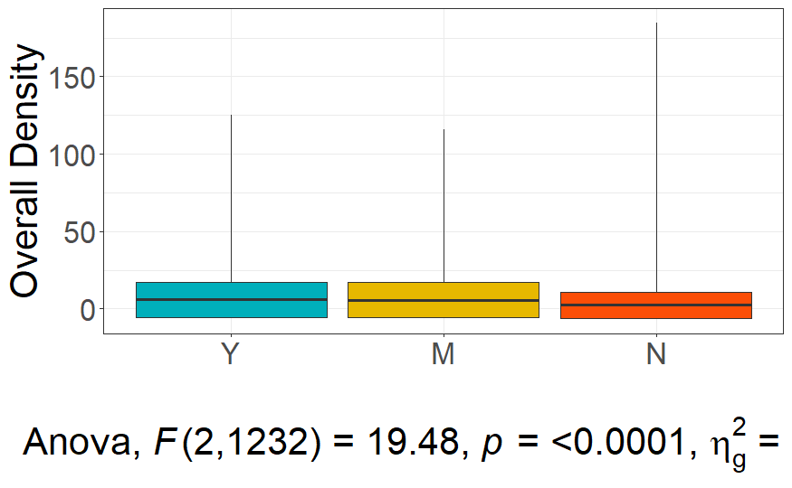

```r
bxp.od<-ggplot(data=OD.stat)+
  scale_fill_manual(values=c("#00AFBB", "#E7B800", "#FC4E07"))+
  geom_boxplot(aes(x=VME_YMN,
                   ymin=min,
                   lower=mean-sd,
                   middle=mean,
                   upper=mean+sd,
                   ymax=max,
                   fill=VME_YMN), stat="identity")+

  theme_bw()+
  theme(text = element_text(size = 25))+
  labs(x=get_test_label(aov.od,row=1, detailed =T), y="Overall Density")+
  theme(axis.title.x = element_text(margin = margin(t = 30)))+
  theme(legend.position = "none") #+

  #theme(axis.title = element_text(size = 25))

#  theme(axis.text = element_text(size = 25))

plot(bxp.od)
```

```r
bxp.od.gap<-gg.gap(bxp.od,
                   segments=c(40,100),
                   tick_width = c(5,200),
                   rel_heights = c(1,0,0.2),
                   ylim=c(0,900))#,
                   #label_size = 24)

plot(bxp.od.gap)

png(file="I:/Papers_development/13 Amy Baco VME skypes SUBMITTED/ANOVAplots/aov_overall_density_msdGT1m2.png", width=8, height=8, units="in", res=500)
```

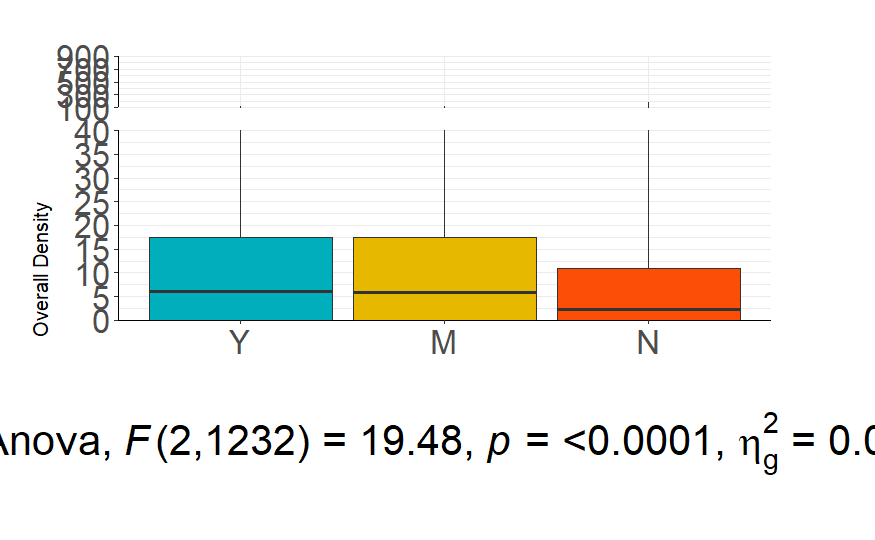

```r
plot(bxp.od.gap)
dev.off()
```

## Total Taxa

```r
bxp.tt<-ggplot(data=TT.stat)+
  scale_fill_manual(values=c("#00AFBB", "#E7B800", "#FC4E07"))+
  geom_boxplot(aes(x=VME_YMN,
                   ymin=min,
                   lower=mean-sd,
                   middle=mean,
                   upper=mean+sd,
                   ymax=max,
                   fill=VME_YMN), stat="identity")+

  theme_bw()+
  theme(text = element_text(size = 25))+
  labs(x=get_test_label(aov.tt,row=1, detailed =T), y="Total Taxa Count")+
  theme(axis.title.x = element_text(margin = margin(t = 30)))+
  theme(legend.position = "none")+
  theme(axis.line = element_line(colour = "black"),# to remove the border to match the other multipanel plots (with broken y axis)
    panel.border = element_blank(),
    panel.background = element_blank()) +
  scale_y_continuous(breaks = seq(0, 10, 1))+
    theme(plot.margin = unit(c(1.2,2.5,1.2,1.2), "cm"))


# bxp.tt.gap<-gg.gap(bxp.tt,
#                    segments=c(17,100),
#                    tick_width = c(5,700),
#                    rel_heights = c(1,0,0.2),
#                    ylim=c(0,800))

plot(bxp.tt)

png(file="I:/Papers_development/13 Amy Baco VME skypes SUBMITTED/ANOVAplots/aov_tt_msdGT1m2.png", width=8, height=8, units="in", res=500)
```

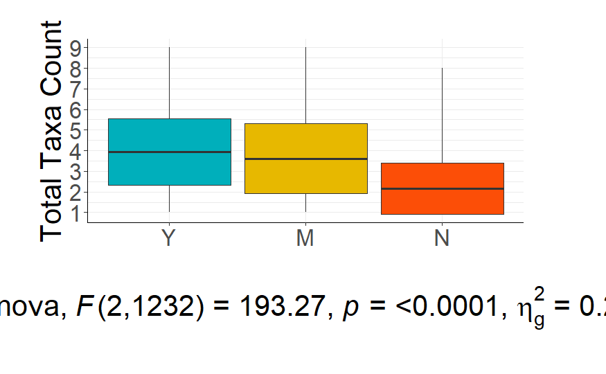

```r
plot(bxp.tt)
dev.off()
```

## Taxa per m2

```r
bxp.tm<-ggplot(data=TM.stat)+
  scale_fill_manual(values=c("#00AFBB", "#E7B800", "#FC4E07"))+
  geom_boxplot(aes(x=VME_YMN,
                   ymin=min,
                   lower=mean-sd,
                   middle=mean,
                   upper=mean+sd,
                   ymax=max,
                   fill=VME_YMN), stat="identity")+

  theme_bw()+
  theme(text = element_text(size = 25))+
  labs(x=get_test_label(aov.tm,row=1, detailed =T), y="Taxa per m2")+
  theme(axis.title.x = element_text(margin = margin(t = 30)))+
  theme(legend.position = "none")


bxp.tm.gap<-gg.gap(bxp.tm,
                   segments=c(3,5),
                   tick_width = c(1,5),
                   rel_heights = c(1,0,0.2),
                   ylim=c(0,20))

plot(bxp.tm.gap)

png(file="I:/Papers_development/13 Amy Baco VME skypes SUBMITTED/ANOVAplots/aov_tm_msdGT1m2.png", width=8, height=8, units="in", res=500)
```

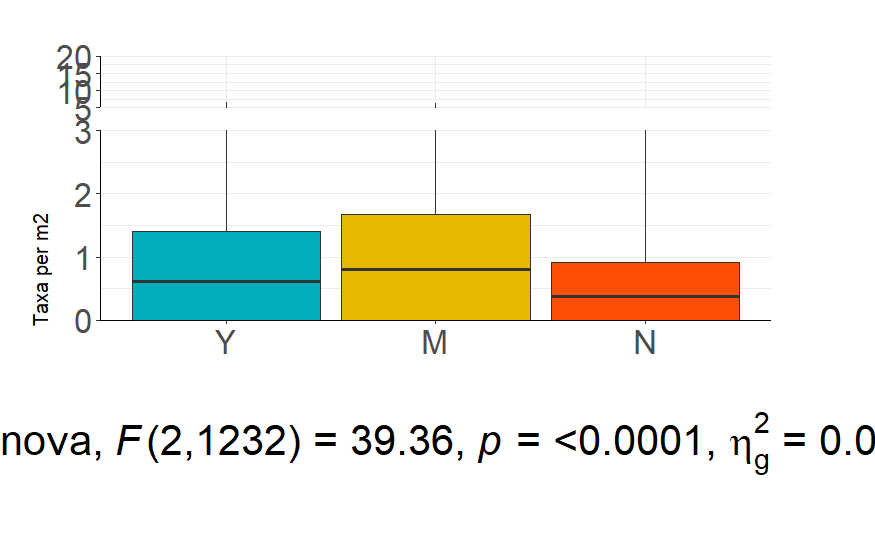

```r
plot(bxp.tm.gap)
dev.off()
```

## Scleractinians (solitary) - problematic!?

```r
bxp.sc<-ggplot(data=SC.stat)+
  scale_fill_manual(values=c("#00AFBB", "#E7B800", "#FC4E07"))+
  geom_boxplot(aes(x=VME_YMN,
                   ymin=min,
                   lower=mean-sd,
                   middle=mean,
                   upper=mean+sd,
                   ymax=max,
                   fill=VME_YMN), stat="identity")+
  theme_bw()+
  theme(text = element_text(size = 25))+
  labs(x=get_test_label(aov.sc,row=1, detailed =T), y="Scleractinians")+
  theme(axis.title.x = element_text(margin = margin(t = 30)))+
  theme(legend.position = "none")


bxp.sc.gap<-gg.gap(bxp.sc,
                   segments=c(15,20),
                   tick_width = c(1,40),
                   rel_heights = c(1,0,0.2),
                   ylim=c(0,100))

plot(bxp.sc.gap)

png(file="I:/Papers_development/13 Amy Baco VME skypes SUBMITTED/ANOVAplots/aov_sc_msdGT1m2.png", width=8, height=8, units="in", res=500)
```

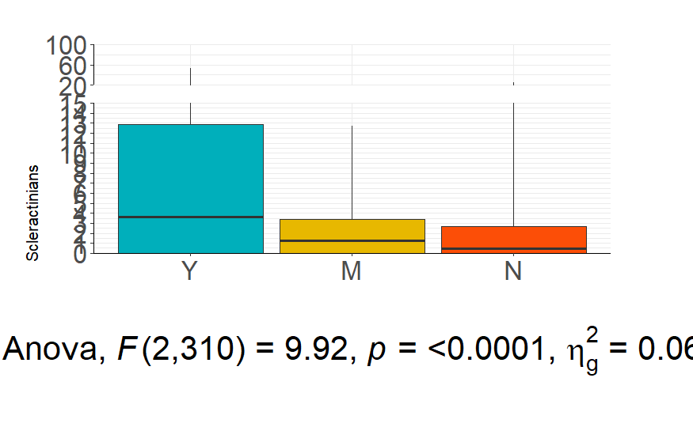

```r
plot(bxp.sc.gap)
dev.off()
```

## Octocorals

```r
OC.stat
```

| VME_YMN | mean | sd | n | min | max |
| --- | --- | --- | --- | --- | --- |
| Y | 1.4670619 | 2.707179 | 224 | 0.02000000 | 22.16625 |
| M | 0.7950741 | 2.291544 | 150 | 0.05135838 | 18.31276 |
| N | 0.2923862 | 1.149579 | 168 | 0.02533403 | 14.73093 |

```r
bxp.oc<-ggplot(data=OC.stat)+
  scale_fill_manual(values=c("#00AFBB", "#E7B800", "#FC4E07"))+
  geom_boxplot(aes(x=VME_YMN,
                   ymin=min,
                   lower=mean-sd,
                   middle=mean,
                   upper=mean+sd,
                   ymax=max,
                   fill=VME_YMN), stat="identity")+

  theme_bw()+
  theme(text = element_text(size = 25))+
  labs(x=get_test_label(aov.oc,row=1, detailed =T), y="Octocorals")+
  theme(axis.title.x = element_text(margin = margin(t = 30)))+
  theme(legend.position = "none")


bxp.oc.gap<-gg.gap(bxp.oc,
                   segments=c(4.5,5),
                   tick_width = c(1,5),
                   rel_heights = c(1,0,0.2),
                   ylim=c(0,25))

plot(bxp.oc.gap)

png(file="I:/Papers_development/13 Amy Baco VME skypes SUBMITTED/ANOVAplots/aov_oc_msdGT1m2.png", width=8, height=8, units="in", res=500)
```

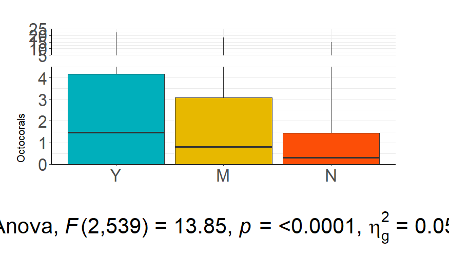

```r
plot(bxp.oc.gap)
dev.off()
```

## Sponges

```r
SP.stat
```

| VME_YMN | mean | sd | n | min | max |
| --- | --- | --- | --- | --- | --- |
| Y | 1.2947888 | 3.7225934 | 177 | 0.05000000 | 43.637387 |
| M | 1.4752650 | 2.2075703 | 158 | 0.03403279 | 11.867916 |
| N | 0.5844921 | 0.9174321 | 201 | 0.02104179 | 6.015038 |

```r
bxp.sp<-ggplot(data=SP.stat)+
  scale_fill_manual(values=c("#00AFBB", "#E7B800", "#FC4E07"))+
  geom_boxplot(aes(x=VME_YMN,
                   ymin=min,
                   lower=mean-sd,
                   middle=mean,
                   upper=mean+sd,
                   ymax=max,
                   fill=VME_YMN), stat="identity")+

  theme_bw()+
  theme(text = element_text(size = 25))+
  labs(x=get_test_label(aov.sp,row=1, detailed =T), y="Sponges")+
  theme(axis.title.x = element_text(margin = margin(t = 30)))+
  theme(legend.position = "none")


bxp.sp.gap<-gg.gap(bxp.sp,
                   segments=c(17,20),
                   tick_width = c(1,50),
                   rel_heights = c(1,0,0.2),
                   ylim=c(0,170))

plot(bxp.sp.gap)

png(file="I:/Papers_development/13 Amy Baco VME skypes SUBMITTED/ANOVAplots/aov_sp_msdGT1m2.png", width=8, height=8, units="in", res=500)
```

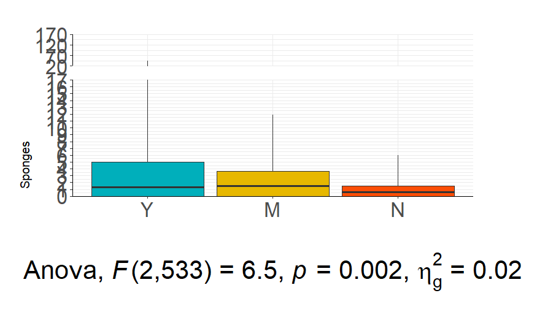

```r
plot(bxp.sp.gap)
dev.off()
```

## Antipatharians (problemaic?)

```r
AN.stat
```

| VME_YMN | mean | sd | n | min | max |
| --- | --- | --- | --- | --- | --- |
| Y | 0.4182730 | 0.6989578 | 97 | 0.02000000 | 4.775541 |
| M | 0.5228431 | 0.5453957 | 91 | 0.03403279 | 3.444259 |
| N | 0.2762293 | 0.4796840 | 81 | 0.03270069 | 3.683444 |

```r
bxp.an<-ggplot(data=AN.stat)+
  scale_fill_manual(values=c("#00AFBB", "#E7B800", "#FC4E07"))+
  geom_boxplot(aes(x=VME_YMN,
                   ymin=min,
                   lower=mean-sd,
                   middle=mean,
                   upper=mean+sd,
                   ymax=max,
                   fill=VME_YMN), stat="identity")+

  theme_bw()+
  theme(text = element_text(size = 25))+
  labs(x=get_test_label(aov.an,row=1, detailed =T), y="Anipatharians")+
  theme(axis.title.x = element_text(margin = margin(t = 30)))+
  theme(legend.position = "none")


bxp.an.gap<-gg.gap(bxp.an,
                   segments=c(1.2,2),
                   tick_width = c(0.2,1),
                   rel_heights = c(1,0,0.2),
                   ylim=c(0,5))

plot(bxp.an.gap)

png(file="I:/Papers_development/13 Amy Baco VME skypes SUBMITTED/ANOVAplots/aov_an_msdGT1m2.png", width=8, height=8, units="in", res=500)
```

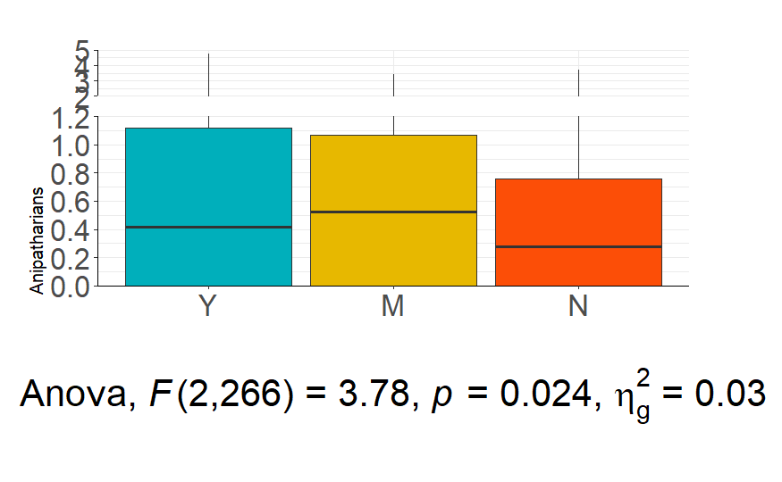

```r
plot(bxp.an.gap)
dev.off()
```

## Pennatulacea

```r
PN.stat
```

| VME_YMN | mean | sd | n | min | max |
| --- | --- | --- | --- | --- | --- |
| Y | 1.9202060 | 2.1267293 | 4 | 0.08527752 | 4.086748 |
| M | 0.6045382 | 0.8006362 | 26 | 0.05135838 | 3.055071 |
| N | 0.1358799 | 0.2038329 | 43 | 0.02769830 | 1.407373 |

```r
bxp.pn<-ggplot(data=PN.stat)+
  scale_fill_manual(values=c("#00AFBB", "#E7B800", "#FC4E07"))+
  geom_boxplot(aes(x=VME_YMN,
                   ymin=min,
                   lower=mean-sd,
                   middle=mean,
                   upper=mean+sd,
                   ymax=max,
                   fill=VME_YMN), stat="identity")+

  theme_bw()+
  theme(text = element_text(size = 25))+
  labs(x=get_test_label(aov.pn,row=1, detailed =T), y="Pennatulacea")+
  theme(axis.title.x = element_text(margin = margin(t = 30)))+
  theme(axis.line = element_line(colour = "black"),# to remove the border to match the other multipanel plots (with broken y axis)
    panel.border = element_blank(),
    panel.background = element_blank()) +
  theme(legend.position = "none")+
    theme(plot.margin = unit(c(1.1,1.1,1.1,1.1), "cm"))


# bxp.an.gap<-gg.gap(bxp.an,
#                    segments=c(1.5,2.5),
#                    tick_width = c(0.5,2),
#                    rel_heights = c(1,0,0.2),
#                    ylim=c(0,4.5))

plot(bxp.pn)

png(file="I:/Papers_development/13 Amy Baco VME skypes SUBMITTED/ANOVAplots/aov_pn_msdGT1m2.png", width=8, height=8, units="in", res=500)
```

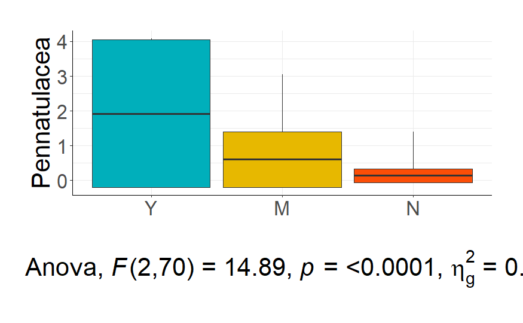

```r
plot(bxp.pn)
dev.off()
```

## Xenophyophores

```r
XE.stat
```

| VME_YMN | mean | sd | n | min | max |
| --- | --- | --- | --- | --- | --- |
| Y | 2.3710937 | 1.8388409 | 7 | 0.51758025 | 5.184332 |
| M | 2.1265178 | 3.2428760 | 38 | 0.06574622 | 12.397092 |
| N | 0.7043184 | 0.8294391 | 34 | 0.05854458 | 3.760485 |

```r
bxp.xe<-ggplot(data=XE.stat)+
  scale_fill_manual(values=c("#00AFBB", "#E7B800", "#FC4E07"))+
  geom_boxplot(aes(x=VME_YMN,
                   ymin=min,
                   lower=mean-sd,
                   middle=mean,
                   upper=mean+sd,
                   ymax=max,
                   fill=VME_YMN), stat="identity")+

  theme_bw()+
  theme(text = element_text(size = 25))+
  labs(x=get_test_label(aov.pn,row=1, detailed =T), y="Xenophyophores")+
  theme(axis.title.x = element_text(margin = margin(t = 30)))+
  theme(axis.line = element_line(colour = "black"),# to remove the border to match the other multipanel plots (with broken y axis)
    panel.border = element_blank(),
    panel.background = element_blank()) +
  theme(legend.position = "none")+
    theme(plot.margin = unit(c(1.1,1.1,1.1,1.1), "cm"))

# bxp.an.gap<-gg.gap(bxp.an,
#                    segments=c(1.5,2.5),
#                    tick_width = c(0.5,2),
#                    rel_heights = c(1,0,0.2),
#                    ylim=c(0,4.5))

plot(bxp.xe)

png(file="I:/Papers_development/13 Amy Baco VME skypes SUBMITTED/ANOVAplots/aov_xe_msdGT1m2.png", width=8, height=8, units="in", res=500)
```

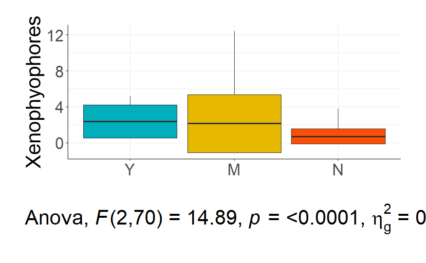

```r
plot(bxp.xe)
dev.off()
```

## Reef framework

```r
RF.stat
```

| VME_YMN | mean | sd | n | min | max |
| --- | --- | --- | --- | --- | --- |
| Y | 80.55882 | 29.31017 | 68 | 4 | 100 |
| M | 37.76471 | 21.46746 | 34 | 5 | 85 |
| N | 11.51852 | 18.36043 | 27 | 1 | 80 |

```r
bxp.rf<-ggplot(data=RF.stat)+
  scale_fill_manual(values=c("#00AFBB", "#E7B800", "#FC4E07"))+
  geom_boxplot(aes(x=VME_YMN,
                   ymin=min,
                   lower=mean-sd,
                   middle=mean,
                   upper=max,
                   ymax=max,
                   fill=VME_YMN), stat="identity")+

  theme_bw()+
  theme(text = element_text(size = 25))+
  labs(x=get_test_label(aov.rf,row=1, detailed =T), y="Percent Scleractinian Framework")+
  theme(axis.title.x = element_text(margin = margin(t = 30)))+
  theme(legend.position = "none")+
  theme(axis.line = element_line(colour = "black"),# to remove the border to match the other multipanel plots (with broken y axis)
    panel.border = element_blank(),
    panel.background = element_blank()) +
  scale_y_continuous(breaks = seq(0, 100, 10))+
    theme(plot.margin = unit(c(1.1,2.5,1.1,1.1), "cm"))


# bxp.an.gap<-gg.gap(bxp.an,
#                    segments=c(1.5,2.5),
#                    tick_width = c(0.5,2),
#                    rel_heights = c(1,0,0.2),
#                    ylim=c(0,4.5))

plot(bxp.rf)

png(file="I:/Papers_development/13 Amy Baco VME skypes SUBMITTED/ANOVAplots/aov_rf_deadlive_msdGT1m2.png", width=8, height=8, units="in", res=500)
```

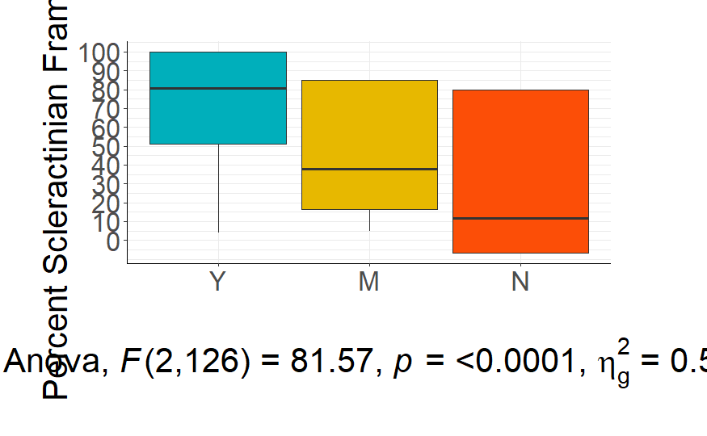

```r
plot(bxp.rf)
dev.off()
```

## Stylasterids

```r
ST.stat
```

| VME_YMN | mean | sd | n | min | max |
| --- | --- | --- | --- | --- | --- |
| Y | 5.114024 | 5.336074 | 48 | 0.19723866 | 27.333333 |
| M | 2.153815 | 3.311789 | 29 | 0.06574622 | 15.335463 |
| N | 0.945486 | 1.083826 | 24 | 0.06574622 | 3.820225 |

```r
bxp.st<-ggplot(data=ST.stat)+
  scale_fill_manual(values=c("#00AFBB", "#E7B800", "#FC4E07"))+
  geom_boxplot(aes(x=VME_YMN,
                   ymin=min,
                   lower=mean-sd,
                   middle=mean,
                   upper=mean+sd,
                   ymax=max,
                   fill=VME_YMN), stat="identity")+

  theme_bw()+
  theme(text = element_text(size = 25))+
  labs(x=get_test_label(aov.rf,row=1, detailed =T), y="Stylasterids")+
  theme(axis.title.x = element_text(margin = margin(t = 30)))+
  theme(legend.position = "none")+
  scale_y_continuous(breaks = seq(0, 100, 10))


bxp.st.gap<-gg.gap(bxp.st,
                   segments=c(11,15),
                   tick_width = c(1,5),
                   rel_heights = c(1,0,0.2),
                   ylim=c(0,30))
plot(bxp.st.gap)

png(file="I:/Papers_development/13 Amy Baco VME skypes SUBMITTED/ANOVAplots/aov_st_msdGT1m2.png", width=8, height=8, units="in", res=500)
```

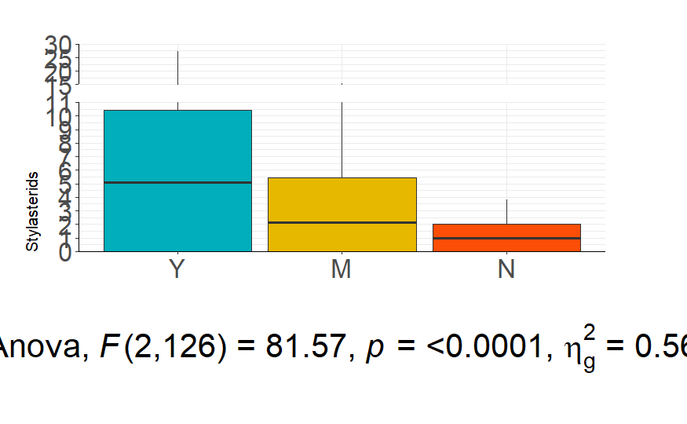

```r
plot(bxp.st.gap)
dev.off()
```